# Choice Task Regression Analysis

Tim Schneegans

28th of January 2021

# Setup

```r
root = "C:/Users/User/GitHub/WebET_Analysis"
path_results = file.path(root, 'results', 'plots', 'fix_task')

knitr::opts_knit$set(root.dir = normalizePath(file.path('..', '..')))

knitr::opts_knit$get("root.dir")
```

```
## [1] "C:\\Users\\User"
```

```r
source(file.path(root, 'utils', 'r', 'geom_split_violin.R'))
source(file.path(root, 'utils', 'r', 'merge_mean_by_subject.R'))
source(file.path(root, 'utils', 'r', 'merge_by_subject.R'))
source(file.path(root, 'utils', 'r', 'summarize_datasets.R'))
source(file.path(root, 'utils', 'r', 'get_packages.R'))
source(file.path(root, 'utils', 'r', 'remove_runs.R'))
source(file.path(root, 'utils', 'r', 'add_log_k.R'))
source(file.path(root, 'utils', 'r', 'remove_na_et_indices.R'))
source(file.path(root, 'utils', 'r', 'add_x_count.R'))

get_packages(c( 'boot',
                'broom',
                'car',
                'compiler',
                'data.table',
                'DHARMa',
                "dplyr",
                'GGally',
                'ggplot2',
                'HLMdiag',
                'Hmisc',
                'influence.ME',
                "ICC",
                "knitr",
                'lme4',
                'lattice',
                'lme4',
                "lmerTest", # Erhalte p-Werte
                'nlme',
                'parallel',
                'readr',
                'reshape',
                'reshape2',
                "rsq",
                'tidyverse',
                "tinytex"))
```

```
##         boot        broom          car     compiler   data.table       DHARMa
##         TRUE         TRUE         TRUE         TRUE         TRUE         TRUE
##        dplyr       GGally      ggplot2      HLMdiag        Hmisc influence.ME
##         TRUE         TRUE         TRUE         TRUE         TRUE         TRUE
##          ICC        knitr         lme4      lattice         lme4     lmerTest
##         TRUE         TRUE         TRUE         TRUE         TRUE         TRUE
##         nlme     parallel        readr      reshape     reshape2          rsq
##         TRUE         TRUE         TRUE         TRUE         TRUE         TRUE
##    tidyverse      tinytex
##         TRUE         TRUE
```

# Read and create datasets

```r
data_subject = read.csv(
    file.path(root, 'data', 'fix_task', 'added_var',
              'data_subject.csv'))

data_trial = read.csv(
    file.path(root, 'data', 'fix_task', 'added_var',
              'data_trial_fix.csv'))

data_et = read.csv(
    file.path(root, 'data', 'fix_task', 'added_var', 'data_et_fix.csv'))

summarize_datasets(data_et, data_trial, data_subject)
```

```
##           name runs n_trials
## 1      data_et  219     3941
## 2   data_trial  219     3941
## 3 data_subject  219        -
```

## Add variables

```r
# Relevel ethnic
data_subject$ethnic = factor(
    data_subject$ethnic,
    levels = c("caucasian", "hispanic", "asian", "black"), # Faktorstufen
    labels = c("caucasian", "hispanic", "asian", "black"))

# Window
grouped = data_trial %>%
    group_by(run_id) %>%
    dplyr::summarise(
        window_diagonal = mean(window_diagonal_max),
        .groups = 'keep')

if ('window_diagonal' %in% names(data_subject)) {
        data_subject = data_subject %>% dplyr::select(!'window_diagonal')
    }
data_subject = merge(data_subject, grouped, by='run_id')

data_trial = merge_by_subject(data_trial, data_subject, 'age')
```

# Screening & Cleaning

Happens in Jupyter Notebook fix_variables_and_analysis.ipynb

## Visualize offset variance

We need two more requirements to our data: 1) at least three trials with a valid option index 2) 40% of the trials have valid ET indices

```r
data_trial = add_x_count(data_trial, data_et)

grouped = data_trial %>%
    group_by(run_id) %>%
    dplyr::summarise(
        n = n(),
        mean = mean(offset),
        sd = sd(offset),
        .groups='keep') %>%
    mutate(sem = sd / sqrt(n)) %>%
    arrange(run_id, mean)

grouped %>% head(5)
```

```
## # A tibble: 5 x 5
## # Groups:   run_id [5]
##   run_id     n   mean     sd     sem
##    <int> <int>  <dbl>  <dbl>   <dbl>
## 1      4    18 0.267  0.185  0.0436
## 2      5    18 0.0745 0.0244 0.00574
## 3      6    18 0.117  0.0586 0.0138
## 4      7    18 0.0878 0.0298 0.00701
## 5     11    18 0.321  0.188  0.0443
```

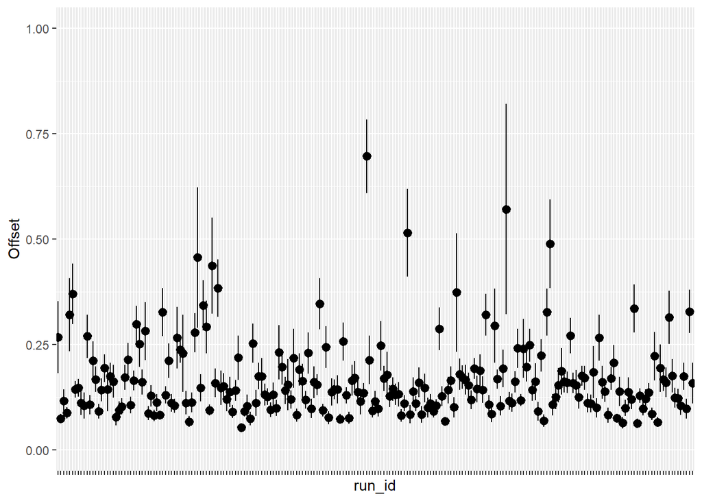

```r
ggplot(grouped, aes(factor(run_id), mean)) +
    geom_pointrange(aes(ymin=mean-1.96*sem,
                        ymax=mean+1.96*sem)) +
    xlab('run_id') +
    ylab('Offset') +
    theme(
        axis.text.x = element_blank(),
        ) +
    coord_cartesian(ylim=c(0, 1))
```

```r
dir.create(file.path(path_results, 'MLA'))
ggsave(file.path(path_results, 'MLA', 'runs_vs_offset.pdf'),
       width=5.5, height=5)
```

# Correlative Analysis

## Scatter matrix

```r
dir.create(file.path(path_results, 'correlations'))
```

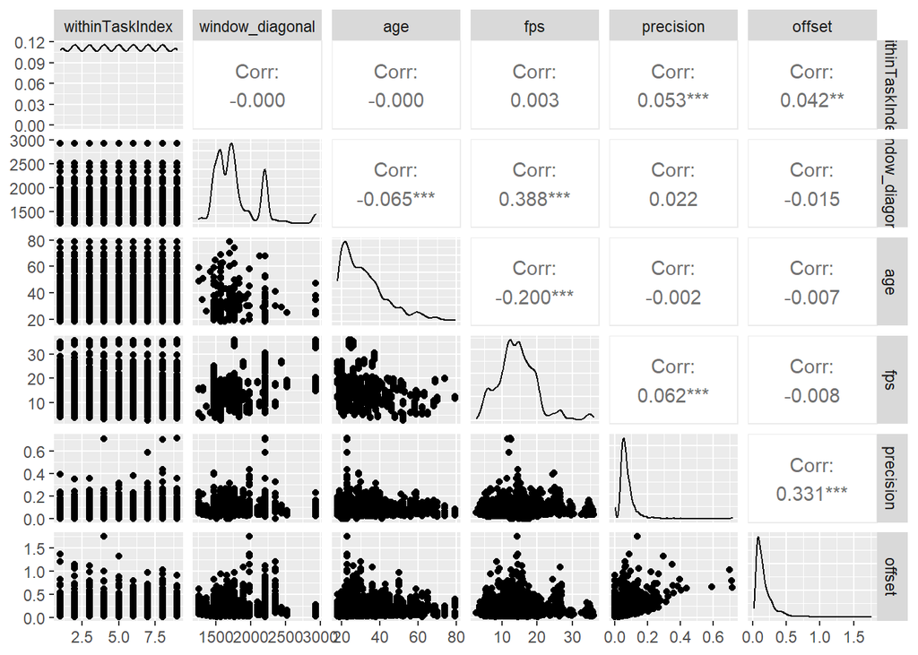

```r
ggpairs(data_trial %>%
    merge_by_subject(data_subject, 'age') %>%
    dplyr::select(
        'withinTaskIndex', 'window_diagonal', 'age', 'fps',
        'precision', 'offset'
        ), progress=F)
```

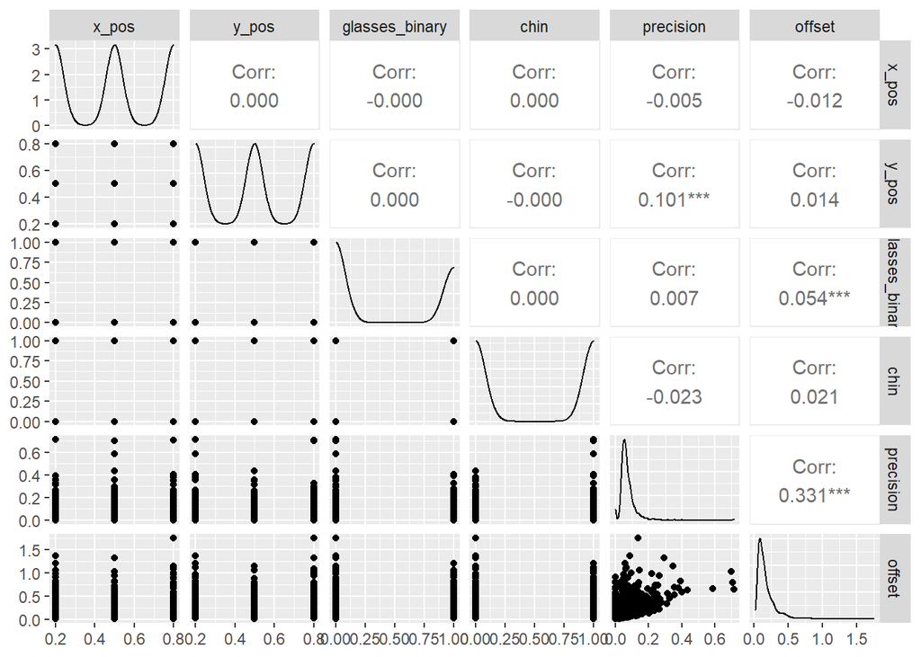

```r
ggsave(file.path(path_results, 'correlations', 'corr_plot_1.pdf'),
       width=5.5, height=5)
ggpairs(data_trial %>% dplyr::select(
    'x_pos', 'y_pos', 'glasses_binary', 'chin', 'precision', 'offset'),
    progress = F)
```

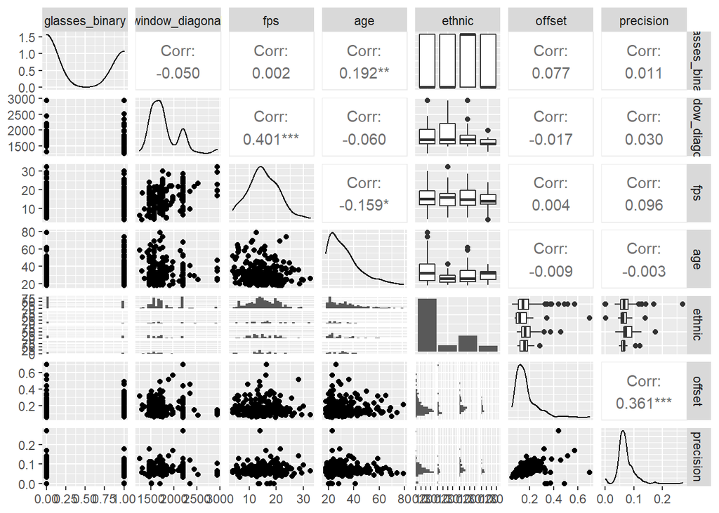

```r
ggsave(file.path(path_results, 'correlations', 'corr_plot_2.pdf'),
       width=5.5, height=5)

grouped = data_trial %>%
    group_by(run_id) %>%
    dplyr::summarise(
        window_diagonal = mean(window_diagonal_max),
        .groups = 'keep')
if ('window_diagonal' %in% names(data_subject)) {
        data_subject = data_subject %>% dplyr::select(!'window_diagonal')
    }
data_subject = merge(data_subject, grouped, by='run_id')

ggpairs(data_subject %>% dplyr::select(
        glasses_binary, window_diagonal, fps,
        age, ethnic,
        offset, precision),
    progress = F)
```

```r
ggsave(file.path(path_results, 'correlations', 'corr_plot_subject.pdf'),
       width=5.5, height=5)
```

# Linear model (Fixed Effects, no MLA)

Average offset=0.17 = 17%

```r
lm_null = lm(offset ~ 1, data = data_trial %>% filter(!is.na(offset)))
summary(lm_null)
```

```
##
## Call:
## lm(formula = offset ~ 1, data = data_trial %>% filter(!is.na(offset)))
##
## Residuals:
##      Min       1Q   Median       3Q      Max
## -0.14772 -0.08325 -0.03706  0.03910  1.58407
##
## Coefficients:
##             Estimate Std. Error t value Pr(>|t|)
## (Intercept) 0.168225   0.002098   80.17   <2e-16 ***
## ---
## Signif. codes:  0 '***' 0.001 '**' 0.01 '*' 0.05 '.' 0.1 ' ' 1
##
## Residual standard error: 0.1317 on 3940 degrees of freedom
```

## LM on subject level

```r
lm_sub_0_control = lm(offset ~ window_diagonal + fps + age + ethnic,
                      data = data_subject)

summary(lm_sub_0_control)
```

```
##
## Call:
## lm(formula = offset ~ window_diagonal + fps + age + ethnic, data = data_subject)
##
## Residuals:
##      Min       1Q   Median       3Q      Max
## -0.10893 -0.05800 -0.02274  0.02507  0.52655
##
## Coefficients:
##                   Estimate Std. Error t value Pr(>|t|)
## (Intercept)      1.727e-01  4.321e-02   3.998 8.86e-05 ***
## window_diagonal -6.236e-06  2.182e-05  -0.286    0.775
## fps              1.610e-04  1.281e-03   0.126    0.900
## age              1.466e-05  5.336e-04   0.027    0.978
## ethnichispanic   8.216e-03  2.451e-02   0.335    0.738
## ethnicasian      1.624e-02  1.683e-02   0.965    0.336
## ethnicblack     -5.169e-03  2.607e-02  -0.198    0.843
## ---
## Signif. codes:  0 '***' 0.001 '**' 0.01 '*' 0.05 '.' 0.1 ' ' 1
##
## Residual standard error: 0.09439 on 210 degrees of freedom
##   (2 observations deleted due to missingness)
## Multiple R-squared:  0.005659,   Adjusted R-squared:  -0.02275
## F-statistic: 0.1992 on 6 and 210 DF,  p-value: 0.9767
```

```r
lm_sub_1 = lm(offset ~ window_diagonal + fps + age + ethnic + glasses_binary,
              data = data_subject)
summary(lm_sub_1)
```

```
##
## Call:
## lm(formula = offset ~ window_diagonal + fps + age + ethnic +
##     glasses_binary, data = data_subject)
##
## Residuals:
##      Min       1Q   Median       3Q      Max
## -0.11231 -0.05873 -0.02695  0.02235  0.53026
##
## Coefficients:
##                   Estimate Std. Error t value Pr(>|t|)
## (Intercept)      1.706e-01  4.324e-02   3.946 0.000108 ***
## window_diagonal -5.041e-06  2.184e-05  -0.231 0.817648
## fps              6.703e-05  1.284e-03   0.052 0.958409
## age             -1.108e-04  5.456e-04  -0.203 0.839345
## ethnichispanic   8.799e-03  2.450e-02   0.359 0.719862
## ethnicasian      1.366e-02  1.699e-02   0.804 0.422184
## ethnicblack     -5.731e-03  2.607e-02  -0.220 0.826213
## glasses_binary   1.463e-02  1.345e-02   1.088 0.277726
## ---
## Signif. codes:  0 '***' 0.001 '**' 0.01 '*' 0.05 '.' 0.1 ' ' 1
##
## Residual standard error: 0.09435 on 209 degrees of freedom
##   (2 observations deleted due to missingness)
## Multiple R-squared:  0.01126,    Adjusted R-squared:  -0.02185
## F-statistic: 0.3401 on 7 and 209 DF,  p-value: 0.9348
```

```r
anova(lm_sub_0_control, lm_sub_1)
```

```
## Analysis of Variance Table
##
## Model 1: offset ~ window_diagonal + fps + age + ethnic
## Model 2: offset ~ window_diagonal + fps + age + ethnic + glasses_binary
##   Res.Df    RSS Df Sum of Sq      F Pr(>F)
## 1    210 1.8711
## 2    209 1.8605  1  0.010543 1.1843 0.2777
```

# MLA

## 1) Emtpy model (intercept only)

ICC = 0.47. 47% of the variance can be explained by the variance between the subjects. Interdependence assumption of the simple linear regression is violated. We should to an MLA

```r
lmer0_io = lmer(
    offset ~ 1 + (1 | run_id),
    data=data_trial,
    REML=FALSE) # FML for comparing different fixed effects

summary(lmer0_io)
```

```
## Linear mixed model fit by maximum likelihood . t-tests use Satterthwaite's method [
## lmerModLmerTest]
## Formula: offset ~ 1 + (1 | run_id)
##    Data: data_trial
##
##      AIC      BIC   logLik deviance df.resid
##  -6645.7  -6626.8   3325.8  -6651.7     3938
##
## Scaled residuals:
##     Min      1Q  Median      3Q     Max
## -4.8894 -0.4914 -0.1046  0.3779 12.5250
##
## Random effects:
##  Groups   Name        Variance Std.Dev.
##  run_id   (Intercept) 0.008091 0.08995
##  Residual             0.009258 0.09622
## Number of obs: 3941, groups:  run_id, 219
##
## Fixed effects:
##              Estimate Std. Error        df t value Pr(>|t|)
## (Intercept) 1.682e-01  6.269e-03 2.190e+02   26.83   <2e-16 ***
## ---
## Signif. codes:  0 '***' 0.001 '**' 0.01 '*' 0.05 '.' 0.1 ' ' 1
```

```r
ICCest(factor(data_trial$run_id), data_trial$offset, alpha=.05, CI.type="THD")
```

```
## $ICC
## [1] 0.4675918
##
## $LowerCI
## [1] 0.4187492
##
## $UpperCI
## [1] 0.5209105
##
## $N
## [1] 219
##
## $k
## [1] 17.99543
##
## $varw
## [1] 0.009258298
##
## $vara
## [1] 0.008131175
```